# Case study 1: How Does a Bike-Share Navigate Speedy Success

Soa-Yu Chan

2021/6/19

## Goal: How do annual members and casual riders use Cyclistic bikes differently?

### Contents of Document

1. Data Source
2. Data Structure and manipulate
3. Data visualizations
4. Preliminary results

### 1. Data Source

This is a public data came from [**Google Data Analytics**](https://www.coursera.org/professional-certificates/google-data-analytics) course in coursera. Cyclistic is a fictional bike-share company located in Chicago with more than 5,800 bicycles and 600 docking stations. The data has been made available by Motivate International Inc. under this [**license**](https://www.divvybikes.com/data-license-agreement). This case study hope to find the difference between annual members and casual riders.

### 2. Data Structure and Manipulate

- `X.U.FEFF.`: Index
- `ride_id`: ID attached to each trip taken
- `rideable_type`: rideable type
- `start_at`: day and time trip started, in CST
- `ended_at`: day and time trip ended, in CST
- `start_station_name`: name of station where trip originated
- `start_station_id`: ID of station where trip originated
- `end_station_name`: name of station where trip terminated
- `end_station_id`: ID of station where trip terminated
- `start_lat`: station latitude where trip originated
- `start_lng`: station longitude where trip originated
- `end_lat`: station latitude where trip terminated
- `end_lng`: station longitude where trip terminated
- `member_casual`: “casual” is a rider who purchased single-ride passes or full-day passes; “member” is a rider who purchased an Annual Membership
- `ride_length_second`: each ride time from trip originated to trip terminated, in second
- `ride_length`: each ride time from start to end, in hh:mm:ss
- `day_of_week`: the day of the week that each ride started

From **2020-04** to **2021-05**.

```r
library(table1)
library(tidyverse)
library(ggplot2)
library(lubridate)
library(scales)

bike_share <- read.csv(file = "D:/Case_Study_1/202004_202105_divvy_tripdata.csv",
               header = T, na.strings = c("", "NA"), encoding = "UTF-8", sep = ",")
glimpse(bike_share)
```

```
Rows: 4,348,052
Columns: 17
$ X.U.FEFF.          <int> 0, 1, 2, 3, 4, 5, 6, 7, 8, 9, 10, 11, 12, 13, 14, 15, 16, 17, 18, 19, 20, 21, 22, 2~
$ ride_id            <chr> "A847FADBBC638E45", "5405B80E996FF60D", "5DD24A79A4E006F4", "2A59BBDF5CDBA725", "27~
$ rideable_type      <chr> "docked_bike", "docked_bike", "docked_bike", "docked_bike", "docked_bike", "docked_~
$ started_at         <chr> "2020-04-26 17:45:14", "2020-04-17 17:08:54", "2020-04-01 17:54:13", "2020-04-07 12~
$ ended_at           <chr> "2020-04-26 18:12:03", "2020-04-17 17:17:03", "2020-04-01 18:08:36", "2020-04-07 13~
$ start_station_name <chr> "Eckhart Park", "Drake Ave & Fullerton Ave", "McClurg Ct & Erie St", "California Av~
$ start_station_id   <chr> "86", "503", "142", "216", "125", "173", "35", "434", "627", "377", "508", "374", "~
$ end_station_name   <chr> "Lincoln Ave & Diversey Pkwy", "Kosciuszko Park", "Indiana Ave & Roosevelt Rd", "Wo~
$ end_station_id     <chr> "152.0", "499.0", "255.0", "657.0", "323.0", "35.0", "635.0", "382.0", "359.0", "50~
$ start_lat          <dbl> 41.8964, 41.9244, 41.8945, 41.9030, 41.8902, 41.8969, 41.8923, 41.8665, 41.8949, 41~
$ start_lng          <dbl> -87.6610, -87.7154, -87.6179, -87.6975, -87.6262, -87.6217, -87.6120, -87.6847, -87~
$ end_lat            <dbl> 41.9322, 41.9306, 41.8679, 41.8992, 41.9695, 41.8923, 41.8957, 41.8747, 41.9035, 41~
$ end_lng            <dbl> -87.6586, -87.7238, -87.6230, -87.6722, -87.6547, -87.6120, -87.6201, -87.6864, -87~
$ member_casual      <chr> "member", "member", "member", "member", "casual", "member", "member", "casual", "ca~
$ ride_length_second <dbl> 1609, 489, 863, 732, 3175, 324, 313, 4549, 344, 1039, 1452, 293, 498, 274, 1441, 21~
$ ride_length        <chr> "0:26:49", "0:08:09", "0:14:23", "0:12:12", "0:52:55", "0:05:24", "0:05:13", "1:15:~
$ day_of_week        <int> 1, 6, 4, 3, 7, 5, 5, 3, 4, 7, 7, 7, 6, 7, 2, 7, 1, 7, 7, 7, 1, 6, 7, 1, 1, 2, 2, 7,~
```

- Add `ride_length_hour`: ride length, in hour
- Add `started_date`: started date, in yyyy-mm-dd
- Add `start_mm_yyyy`: started year-month, in yyyy-mm

```r
bike_share$ride_length_hour <- ((bike_share$ride_length_second + 0.001)/3600) - (0.001 / 3600)
bike_share$started_date <- as_date(ymd_hms(bike_share$started_at))
bike_share$start_mm_yyyy <- format_ISO8601(bike_share$started_date, precision = "ym")
```

- Some trip characteristic between casual riders and annual members

```r
table1(~ factor(day_of_week) + ride_length_hour + factor(rideable_type) + start_mm_yyyy | factor(member_casual), data = bike_share)
```

|  | casual (N=1820638) | member (N=2527414) | Overall (N=4348052) |
| --- | --- | --- | --- |
| factor(day_of_week) |  |  |  |
| 1 | 349624 (19.2%) | 332561 (13.2%) | 682185 (15.7%) |
| 2 | 201620 (11.1%) | 336647 (13.3%) | 538267 (12.4%) |
| 3 | 184237 (10.1%) | 349638 (13.8%) | 533875 (12.3%) |
| 4 | 193556 (10.6%) | 369882 (14.6%) | 563438 (13.0%) |
| 5 | 201598 (11.1%) | 364234 (14.4%) | 565832 (13.0%) |
| 6 | 261909 (14.4%) | 377981 (15.0%) | 639890 (14.7%) |
| 7 | 428094 (23.5%) | 396471 (15.7%) | 824565 (19.0%) |
| ride_length_hour |  |  |  |
| Mean (SD) | 0.725 (6.07) | 0.264 (1.40) | 0.457 (4.08) |
| Median [Min, Max] | 0.344 [0, 928] | 0.188 [0, 979] | 0.238 [0, 979] |
| factor(rideable_type) |  |  |  |
| classic_bike | 265526 (14.6%) | 578053 (22.9%) | 843579 (19.4%) |
| docked_bike | 1181475 (64.9%) | 1434720 (56.8%) | 2616195 (60.2%) |
| electric_bike | 373637 (20.5%) | 514641 (20.4%) | 888278 (20.4%) |
| start_mm_yyyy |  |  |  |
| 2020-04 | 23610 (1.3%) | 61115 (2.4%) | 84725 (1.9%) |
| 2020-05 | 86844 (4.8%) | 113258 (4.5%) | 200102 (4.6%) |
| 2020-06 | 154551 (8.5%) | 187985 (7.4%) | 342536 (7.9%) |
| 2020-07 | 268688 (14.8%) | 281047 (11.1%) | 549735 (12.6%) |
| 2020-08 | 288639 (15.9%) | 330953 (13.1%) | 619592 (14.2%) |
| 2020-09 | 230072 (12.6%) | 300754 (11.9%) | 530826 (12.2%) |
| 2020-10 | 144529 (7.9%) | 242213 (9.6%) | 386742 (8.9%) |
| 2020-11 | 87911 (4.8%) | 170940 (6.8%) | 258851 (6.0%) |
| 2020-12 | 29997 (1.6%) | 101142 (4.0%) | 131139 (3.0%) |
| 2021-01 | 18117 (1.0%) | 78715 (3.1%) | 96832 (2.2%) |
| 2021-02 | 10131 (0.6%) | 39491 (1.6%) | 49622 (1.1%) |
| 2021-03 | 84032 (4.6%) | 144462 (5.7%) | 228494 (5.3%) |
| 2021-04 | 136601 (7.5%) | 200624 (7.9%) | 337225 (7.8%) |
| 2021-05 | 256916 (14.1%) | 274715 (10.9%) | 531631 (12.2%) |

- Casual Riders Top 10 Trip

```r
bike_share %>%
  group_by(start_station_name, end_station_name) %>%
  filter(member_casual == 'casual') %>%
  drop_na() %>%
  summarize(count_start_end = n(), average_rider_length = mean(ride_length_hour) * 60) %>%
  arrange(desc(count_start_end)) %>%
  `colnames<-`(c("Start station name", "End station name", "Count", "Average minutes per ride")) %>%
  head(n=10)
```

| Start station name | End station name | Count | Average minutes per ride |
| --- | --- | --- | --- |
| Streeter Dr & Grand Ave | Streeter Dr & Grand Ave | 8341 | 56.88748 |
| Lake Shore Dr & Monroe St | Lake Shore Dr & Monroe St | 7937 | 51.38747 |
| Millennium Park | Millennium Park | 6528 | 57.40011 |
| Buckingham Fountain | Buckingham Fountain | 5999 | 75.02578 |
| Michigan Ave & Oak St | Michigan Ave & Oak St | 4842 | 56.26027 |
| Indiana Ave & Roosevelt Rd | Indiana Ave & Roosevelt Rd | 4584 | 62.63818 |
| Fort Dearborn Dr & 31st St | Fort Dearborn Dr & 31st St | 3917 | 69.82106 |
| Michigan Ave & 8th St | Michigan Ave & 8th St | 3795 | 62.51083 |
| Theater on the Lake | Theater on the Lake | 3634 | 54.81892 |
| Shore Dr & 55th St | Shore Dr & 55th St | 3610 | 68.68639 |

- Annual Members Top 10 Trip

```r
bike_share %>%
  group_by(start_station_name, end_station_name) %>%
  filter(member_casual == 'member') %>%
  drop_na() %>%
  summarize(count_start_end = n(), average_rider_length = mean(ride_length_hour)*60) %>%
  arrange(desc(count_start_end)) %>%
  `colnames<-`(c("Start station name", "End station name", "Count", "Average minutes per ride")) %>%
  head(n=10)
```

| Start station name | End station name | Count | Average minutes per ride |
| --- | --- | --- | --- |
| MLK Jr Dr & 29th St | State St & 33rd St | 1519 | 7.546039 |
| Ellis Ave & 60th St | Ellis Ave & 55th St | 1416 | 5.208898 |
| State St & 33rd St | MLK Jr Dr & 29th St | 1350 | 9.520185 |
| Ellis Ave & 55th St | Ellis Ave & 60th St | 1328 | 5.997691 |
| Clark St & Elm St | Clark St & Elm St | 1253 | 17.044759 |
| Lake Shore Dr & Wellington Ave | Lake Shore Dr & Wellington Ave | 1231 | 23.366342 |
| Lakefront Trail & Bryn Mawr Ave | Lakefront Trail & Bryn Mawr Ave | 1220 | 27.303784 |
| Lake Shore Dr & Belmont Ave | Lake Shore Dr & Belmont Ave | 1200 | 27.730819 |
| Burnham Harbor | Burnham Harbor | 1167 | 25.676678 |
| Streeter Dr & Grand Ave | Streeter Dr & Grand Ave | 1146 | 23.127022 |

### 3. Data Visualizations (Bar Chart - Annual Member vs. Casual rider)

##### Visualization on Month Year

- Casual rider has less trip during winter season compare to annual member(Fig.1).
- Annual member spend less time than casual rider for each trip(Fig.2).

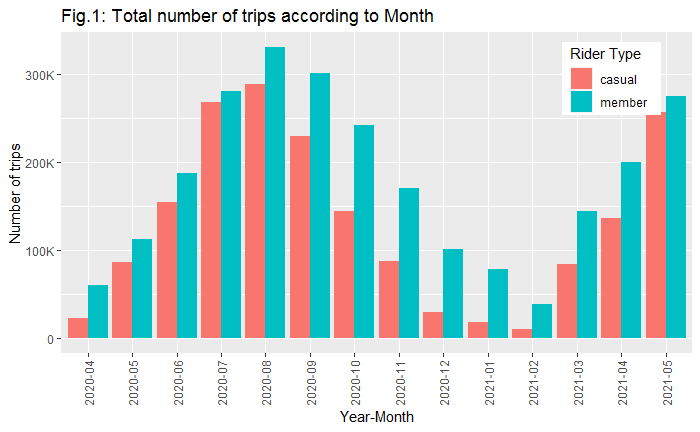

```r
ggplot(data = bike_share)+
  geom_bar( position = 'dodge', mapping = aes(x = factor(start_mm_yyyy), fill = member_casual)) +
  theme(axis.text.x = element_text(angle = 90, vjust = 0.5, hjust = 1)) +
  labs(title = 'Fig.1: Total number of trips according to Month',
       x = 'Year-Month', y = 'Number of trips', fill='Rider Type') +
  scale_y_continuous(breaks = c(0,100000,200000,300000,400000),
                     labels = c("0","100K","200K","300K","400K")) +
  theme(legend.position = c(.95, .97),
        legend.justification = c("right", "top"),
        legend.box.just = "right",
        legend.margin = margin(2, 10, 2, 6))
```

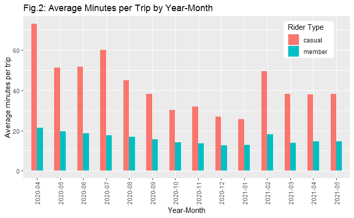

```r
t2 <- bike_share %>%
  group_by(start_mm_yyyy, member_casual) %>%
  summarize(average_ride_length = mean(ride_length_hour*60), sum_ride_length = sum(ride_length_hour))

ggplot(t2, aes(x = start_mm_yyyy, y = average_ride_length,  fill = member_casual)) +
  geom_bar(stat = "identity", position = position_dodge(), width =  0.5) +
  theme(axis.text.x = element_text(angle = 90, vjust = 0.5, hjust = 1)) +
  labs(title = 'Fig.2: Average Minutes per Trip by Year-Month',
       x = 'Year-Month', y = 'Average minutes per trip', fill = 'Rider Type') +
  theme(legend.position = c(.95, .97),
        legend.justification = c("right", "top"),
        legend.box.just = "right",
        legend.margin = margin(2, 10, 2, 6))
```

##### Visualization on Day of Week

- Much more trip during weekend for casual riders(Fig.3).
- No significant difference from sunday to saturday for annual members(Fig.3).
- Also, casual rider spend more time than annual member for each trip(Fig.4).

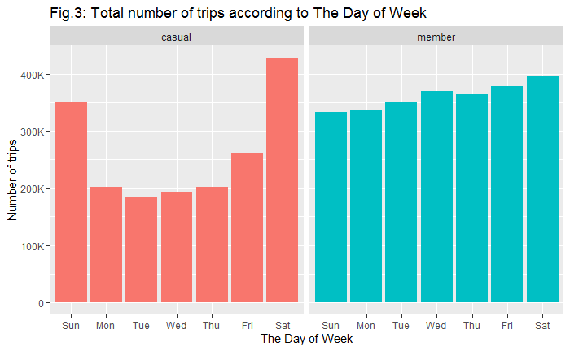

```r
ggplot(data = bike_share) +
  geom_bar(mapping = aes(x = factor(day_of_week), fill = member_casual)) +
  facet_wrap(~member_casual) +
  labs(title = 'Fig.3: Total number of trips according to The Day of Week',
   x = 'The Day of Week', y = 'Number of trips', fill = 'Rider Type') +
  scale_x_discrete(breaks = 1:7,
                   labels = c("Sun", "Mon", "Tue", "Wed", "Thu", "Fri", "Sat")) +
  scale_y_continuous(breaks = c(0, 100000, 200000, 300000, 400000),
                   labels = c("0", "100K", "200K", "300K", "400K")) +
  theme(legend.position = 'none')
```

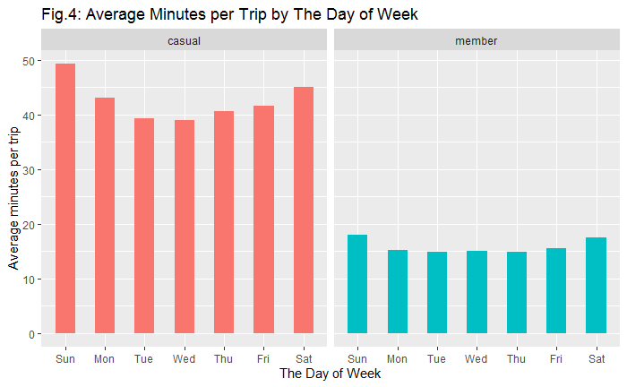

```r
t3 <- bike_share %>%
  group_by(day_of_week, member_casual) %>%
  summarize(average_ride_length = mean(ride_length_hour*60), sum_ride_length = sum(ride_length_hour))

ggplot(t3, aes(x = factor(day_of_week), y = average_ride_length, fill = member_casual)) +
  geom_bar(stat = "identity", position = position_dodge(), width = 0.5) +
  facet_wrap(~member_casual) +
  labs(title = 'Fig.4: Average Minutes per Trip by The Day of Week',
       x = 'The Day of Week', y = 'Average minutes per trip', fill = 'Rider Type') +
  scale_x_discrete(breaks = 1:7,
                   labels = c("Sun", "Mon", "Tue", "Wed", "Thu", "Fri", "Sat")) +
  theme(legend.position = 'none')
```

##### Visualization on Rideable Type

- For annual members: No docked_bike trip after 2021-01. Only classic_bike and electric_bike(Fig.5).
- For casual members: Total number of Classic_bike trip portion larger than docked_bike trip since 2020-12(Fig.5).
- docked_bike spend more average time than classic_bike per trip(Fig.6).

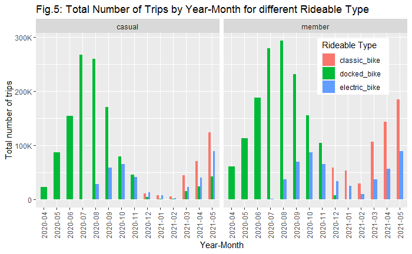

```r
t5 <- bike_share %>%
  group_by(start_mm_yyyy, member_casual, rideable_type) %>%
  summarize(average_ride_length = mean(ride_length_hour * 60), sum_ride_length = sum(ride_length_hour), sum_trip = n())

ggplot(t5, aes(x = start_mm_yyyy, y = sum_trip,  fill = rideable_type)) +
  geom_bar(stat = "identity", position = position_dodge(), width =  0.5) +
  facet_wrap(~member_casual) +
  theme(axis.text.x = element_text(angle = 90, vjust = 0.5, hjust = 1)) +
  labs(title = 'Fig.5: Total Number of Trips by Year-Month for different Rideable Type',
       x = 'Year-Month', y = 'Total number of trips', fill = 'Rideable Type') +
  scale_y_continuous(breaks = c(0, 100000, 200000, 300000, 400000),
                     labels = c("0", "100K", "200K", "300K", "400K")) +
  theme(legend.position = c(.95, .97),
        legend.justification = c("right", "top"),
        legend.box.just = "right",
        legend.margin = margin(2, 10, 2, 6))
```

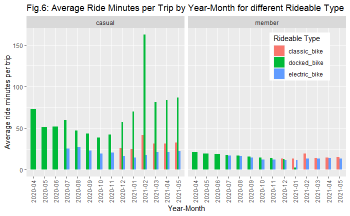

```r
ggplot(t5, aes(x = start_mm_yyyy, y = average_ride_length,  fill = rideable_type)) +
  geom_bar(stat = "identity", position = position_dodge(), width = 0.5) +
  facet_wrap(~member_casual) +
  theme(axis.text.x = element_text(angle = 90, vjust = 0.5, hjust = 1)) +
  labs(title = 'Fig.6: Average Ride Minutes per Trip by Year-Month for different Rideable Type',
       x = 'Year-Month', y = 'Average ride minutes per trip', fill = 'Rideable Type') +
  theme(legend.position = c(.95, .97),
        legend.justification = c("right", "top"),
        legend.box.just = "right",
        legend.margin = margin(2, 10, 2, 6))
```

### 4. Preliminary results

- Change all docked_bike to classic_bike. It can save time for riders.
- Add a half-year annual member to pricing plans. Because many casual riders not use in winter.
- Set more docking station near office zone. Annual member use Cyclistic to commute to work each day.